# R Notebook

14 December 2021

First attempt at DADA2 analysis for the 12S Amalga samples using the NOAA Linux VM.

```r
# set the working directory for this notebook and load packages

# if (!requireNamespace("BiocManager", quietly = TRUE))
#     install.packages("BiocManager")
# BiocManager::install("dada2", version = "3.15")
```

```r
library(dada2)
library(dplyr)
```

```r
path <- "../trimmed"
list.files(path)
```

All I really want to do is visualize the data so that I can see what the read quality looks like and where I should trim the crummy bases.

```r
fnFs <- sort(list.files(path, pattern="_R1.fastq", full.names = TRUE))

fnRs <- sort(list.files(path, pattern="_R2.fastq", full.names = TRUE))
# Extract sample names, assuming filenames have format: SAMPLENAME_XXX.fastq
sample.names <- sapply(strsplit(basename(fnFs), "_"), `[`, 1)
```

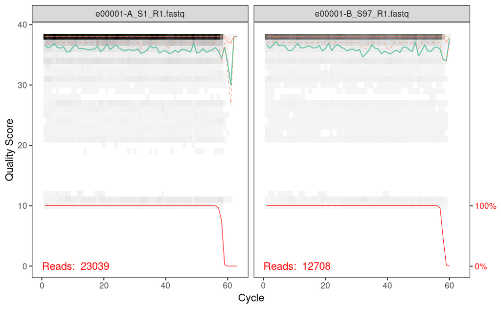

```r
plotQualityProfile(fnFs[1:2])
```

Wow, those quality scores are awesome. Maybe just a little drop in quality at >60 bp.

Look at R2

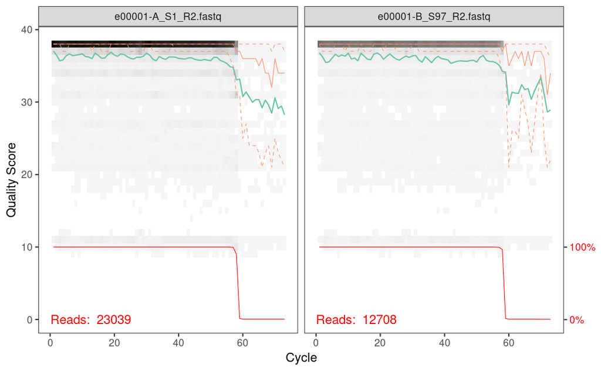

```r
plotQualityProfile(fnRs[1:2])
```

Fantastic quality up to 60 bp and then it decreases, but it’s still around Q30.

```r
# Place filtered files in filtered/ subdirectory
filtFs <- file.path("../filtered", paste0(sample.names, "_F_filt.fastq.gz"))
filtRs <- file.path("../filtered", paste0(sample.names, "_R_filt.fastq.gz"))
names(filtFs) <- sample.names
names(filtRs) <- sample.names

# fFs <- file.path("../filtered",paste0(sample.names,"_F_filt.fastq.gz"))
# fRs <- file.path("../filtered",paste0(sample.names,"_R_filt.fastq.gz"))
# names(fFs) <- sample.names
# names(fRs) <- sample.names
```

I think there’s something funky going on here, which is why none of the files are going through the filter.

note: relaxing the maxEE (expected errors) for the reverse read and removing the truncation length parameter allowed for reads to be retained.

```r
# relaxing expected errors for R2 and remvoing truncLen
out <- filterAndTrim(fnFs, filtFs, fnRs, filtRs,
              maxN=0, maxEE=c(2,5), truncQ=2, rm.phix=TRUE,
              compress=TRUE, multithread=TRUE)
head(out)
```

```
                       reads.in reads.out
e00001-A_S1_R1.fastq      23039     22888
e00001-B_S97_R1.fastq     12708     12671
e00001-C_S193_R1.fastq     9375      9354
e00002-A_S2_R1.fastq        305       301
e00002-B_S98_R1.fastq     20066     19992
e00002-C_S194_R1.fastq    17415     17374
```

Supposedly, these are 75 bp reads, but including ANY truncLen values causes all reads to be filtered and none to be retained. So I’m going to ditch that parameter entirely and play with the maxEE parameter some more.

```r
# default expected errors for R2 but removing truncLen
moreEEs <- filterAndTrim(fnFs, filtFs, fnRs, filtRs,
              maxN=0, maxEE=c(2,2), truncQ=2, rm.phix=TRUE,
              compress=TRUE, multithread=TRUE)
head(moreEEs)
```

```
                       reads.in reads.out
e00001-A_S1_R1.fastq      23039     22649
e00001-B_S97_R1.fastq     12708     12536
e00001-C_S193_R1.fastq     9375      9272
e00002-A_S2_R1.fastq        305       289
e00002-B_S98_R1.fastq     20066     19788
e00002-C_S194_R1.fastq    17415     17165
```

Alright, not surprisingly, that filtered out a few more reads for every sample.

Let’s stick with the more stringent filter since we still retain 98% of reads.

Actually, let’s see if tightening up the maxEE actually changes things much:

```r
# default expected errors for R2 but removing truncLen
tightEEs <- filterAndTrim(fnFs, filtFs, fnRs, filtRs,
              maxN=0, maxEE=c(1,2), truncQ=2, rm.phix=TRUE,
              compress=TRUE, multithread=TRUE) # On Windows set multithread=FALSE
head(tightEEs)
```

```
                       reads.in reads.out
e00001-A_S1_R1.fastq      23039     21966
e00001-B_S97_R1.fastq     12708     12236
e00001-C_S193_R1.fastq     9375      9053
e00002-A_S2_R1.fastq        305       278
e00002-B_S98_R1.fastq     20066     19221
e00002-C_S194_R1.fastq    17415     16668
```

For now, let’s go with the tight maxEE values. (this will also speed up processing)

## Learn the error rates

```r
errF <- learnErrors(filtFs, multithread=TRUE)
```

```
100336009 total bases in 1742256 reads from 124 samples will be used for learning the error rates.
```

```r
errR <- learnErrors(filtRs, multithread=TRUE)
```

```
100717786 total bases in 1742256 reads from 124 samples will be used for learning the error rates.
```

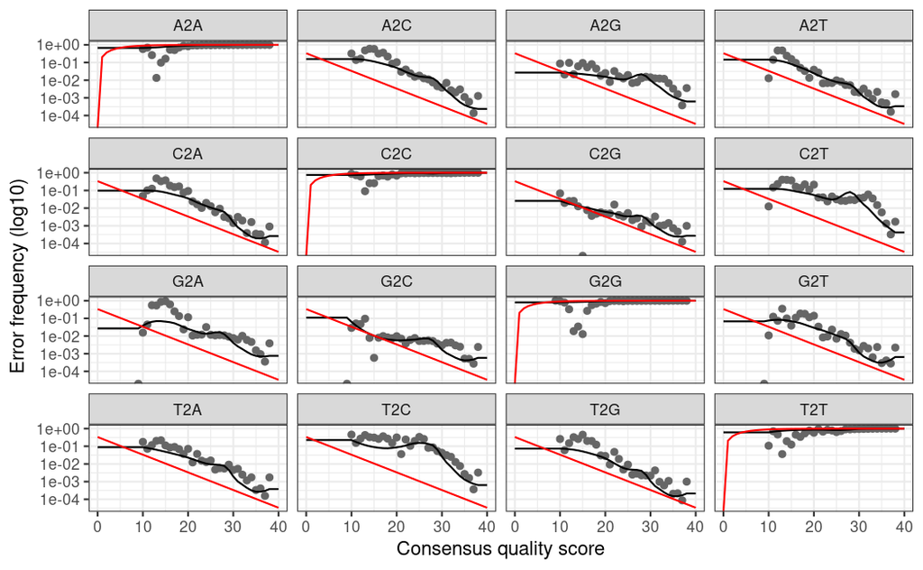

```r
plotErrors(errF, nominalQ=TRUE)
```

Hmmm. These fits actually aren’t as good as I would expect, particularly for T2C. Most of the other fits look okay.

Here’s a question - is there a way to account for this potential mismatch in the expected vs. observed errors by changing parameters for DADA2?

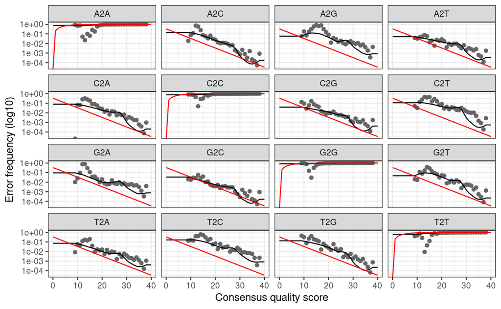

```r
plotErrors(errR, nominalQ=TRUE)
```

Those all look fine.

Proceeding with sample inference.

## Dereplicate

- this step was included in Wes’s dada2 procedure… but not mine, previously. I assume it just reduces computation time for the dada2 algorithm

```r
# dereplicate Fastqs prior to inference
filtered_files_derepF<-derepFastq(fls=filtFs, verbose = FALSE)

# and the reverse files
filtered_files_derepR<-derepFastq(fls=filtRs, verbose = FALSE)
```

## Sample inference

Here is where the core DADA2 algorithm is implemented.

```r
dadaFs <- dada(filtered_files_derepF, err=errF, multithread=TRUE)

dadaRs <- dada(filtered_files_derepR, err=errR, multithread=TRUE)
```

```r
dadaFs[[1]]
```

```
dada-class: object describing DADA2 denoising results
29 sequence variants were inferred from 3303 input unique sequences.
Key parameters: OMEGA_A = 1e-40, OMEGA_C = 1e-40, BAND_SIZE = 16
```

```r
dadaRs[[1]]
```

```
dada-class: object describing DADA2 denoising results
29 sequence variants were inferred from 2684 input unique sequences.
Key parameters: OMEGA_A = 1e-40, OMEGA_C = 1e-40, BAND_SIZE = 16
```

Only 29 sequence variants! So few!! ** Here there is an option to pool info across samples to be more sensitive to ASV that may be at low frequency.

It might be worth just playing with this option for a minute before proceeding?

```r
# seems like pseudo-pooling might be the happy hybrid here
dadaFspool <- dada(filtered_files_derepF, err=errF, multithread=TRUE, pool="pseudo")
```

And check out if that recovered anything more:

```r
dadaFspool[[1]]
```

```
dada-class: object describing DADA2 denoising results
45 sequence variants were inferred from 3303 input unique sequences.
Key parameters: OMEGA_A = 1e-40, OMEGA_C = 1e-40, BAND_SIZE = 16
```

Okay, so that actually did exactly what we would expect - it increased the number of ASVs from 29 to 45 based on adding weight to rare ASVs. Whether that actually increases the number of species remains to be seen.

Let’s do the same pseudo-pool for Reverse reads

```r
# seems like pseudo-pooling might be the happy hybrid here
dadaRspool <- dada(filtered_files_derepR, err=errR, multithread=TRUE, pool="pseudo")
```

```r
dadaRspool[[1]]
```

```
dada-class: object describing DADA2 denoising results
45 sequence variants were inferred from 2684 input unique sequences.
Key parameters: OMEGA_A = 1e-40, OMEGA_C = 1e-40, BAND_SIZE = 16
```

## Merge paired-end reads

For both the pseudo-pool and original dataset

important note from DADA2: F and R reads are expected to overlap by at least 12 bases, and are identical to each other in the overlap region (but these conditions can be changed via function arguments).

note: the default parameters discarded way too many of the reads; try reducing the overlap

```r
mergers <- mergePairs(dadaFs, filtered_files_derepF, dadaRs, filtered_files_derepR, minOverlap = 2,
  maxMismatch = 2, verbose=TRUE)
```

```
20756 paired-reads (in 71 unique pairings) successfully merged out of 21919 (in 116 pairings) input.
11899 paired-reads (in 82 unique pairings) successfully merged out of 12167 (in 105 pairings) input.
8731 paired-reads (in 66 unique pairings) successfully merged out of 8995 (in 81 pairings) input.
227 paired-reads (in 11 unique pairings) successfully merged out of 267 (in 14 pairings) input.
18582 paired-reads (in 74 unique pairings) successfully merged out of 19163 (in 106 pairings) input.
16502 paired-reads (in 94 unique pairings) successfully merged out of 16650 (in 106 pairings) input.
19241 paired-reads (in 82 unique pairings) successfully merged out of 20464 (in 143 pairings) input.
15880 paired-reads (in 71 unique pairings) successfully merged out of 16699 (in 110 pairings) input.
16073 paired-reads (in 69 unique pairings) successfully merged out of 16330 (in 85 pairings) input.
21532 paired-reads (in 77 unique pairings) successfully merged out of 23371 (in 138 pairings) input.
14777 paired-reads (in 65 unique pairings) successfully merged out of 15343 (in 91 pairings) input.
13526 paired-reads (in 76 unique pairings) successfully merged out of 13944 (in 94 pairings) input.
15225 paired-reads (in 43 unique pairings) successfully merged out of 16457 (in 86 pairings) input.
11318 paired-reads (in 50 unique pairings) successfully merged out of 11781 (in 72 pairings) input.
3204 paired-reads (in 30 unique pairings) successfully merged out of 3322 (in 45 pairings) input.
```

[output cut: 597 more lines]

```r
# Inspect the merger data.frame from the first sample
head(mergers[[1]])
```

|  | sequence | abundance | forward | reverse | nmatch | nmismatch | nindel | prefer | accept |
| --- | --- | --- | --- | --- | --- | --- | --- | --- | --- |
| 1 | ACGGCGACAGGTTCAGAGTTCTACAGTCCGACGATCACTGGGATTAGATACCCCGTGACTAGAGGAGCCTGTTCTAAGATCGGAAGAGCACACGTCTGAACTCCAGTCACTG | 11736 | 1 | 1 | 4 | 0 | 0 | 2 | TRUE |
| 2 | ACGGCGACAGGTTCAGAGTTCTACAGTCCGACGATCACTGGGATTAGATACCCCATGACTAGAGGAGCCTGTTCTAAGATCGGAAGAGCACACGTCTGAACTCCAGTCACTG | 1990 | 2 | 2 | 4 | 0 | 0 | 2 | TRUE |
| 3 | ACTATGCCTAGCCCTAAACCTTGGTAATATATCACATACCCTACCCGCCTGGGAACTACGAGCACCAGCTTAAAACCCAAAGGACTTGGCGGTGCTTTAGACCCCC | 1519 | 3 | 4 | 9 | 0 | 0 | 2 | TRUE |
| 4 | GCGACAGGTTCAGAGTTCTACAGTCCGACGATCACTGGGATTAGATACCCCAGTCACCTAGAGGAGCCTGTTCTAAGATCGGAAGAGCACACGTCTGAACTCCAGTCAC | 1385 | 4 | 3 | 6 | 0 | 0 | 2 | TRUE |
| 5 | ACTATGCCTAGCCCTAAACCTTGATAGTGACCTACGCCCACTATCCGCCTGGGAACTACGAGCATCAGCTTGAAACCCAAAGGACTTGGCGGTGCTTTAGATCCAC | 1198 | 5 | 5 | 9 | 0 | 0 | 2 | TRUE |
| 6 | ACTATGCCTAGCCCTAAACATTGATAGTATATTACACCCGCTATCCGCCTGGGAACTACGAGCATCAGCTTAAAACCCAAAGGACTTGGCGGTGCTTTAGATCCAC | 829 | 6 | 6 | 9 | 0 | 0 | 2 | TRUE |

```r
NA
```

```r
poolmergers <- mergePairs(dadaFspool, filtered_files_derepF, dadaRspool, filtered_files_derepR, minOverlap = 1, maxMismatch = 2, verbose=TRUE)
```

```
21301 paired-reads (in 148 unique pairings) successfully merged out of 21919 (in 184 pairings) input.
Duplicate sequences in merged output.
12024 paired-reads (in 146 unique pairings) successfully merged out of 12209 (in 160 pairings) input.
8939 paired-reads (in 114 unique pairings) successfully merged out of 9048 (in 123 pairings) input.
260 paired-reads (in 28 unique pairings) successfully merged out of 273 (in 36 pairings) input.
18857 paired-reads (in 136 unique pairings) successfully merged out of 19166 (in 153 pairings) input.
16611 paired-reads (in 145 unique pairings) successfully merged out of 16656 (in 154 pairings) input.
19816 paired-reads (in 151 unique pairings) successfully merged out of 20501 (in 186 pairings) input.
16133 paired-reads (in 132 unique pairings) successfully merged out of 16694 (in 157 pairings) input.
Duplicate sequences in merged output.
16191 paired-reads (in 128 unique pairings) successfully merged out of 16382 (in 141 pairings) input.
22190 paired-reads (in 157 unique pairings) successfully merged out of 23372 (in 196 pairings) input.
14877 paired-reads (in 125 unique pairings) successfully merged out of 15363 (in 145 pairings) input.
13787 paired-reads (in 137 unique pairings) successfully merged out of 13950 (in 151 pairings) input.
15856 paired-reads (in 116 unique pairings) successfully merged out of 16540 (in 160 pairings) input.
```

[output cut: 674 more lines]

```r
# Inspect the merger data.frame from the first sample
head(poolmergers[[1]])
```

|  | sequence | abundance | forward | reverse | nmatch | nmismatch | nindel | prefer | accept |
| --- | --- | --- | --- | --- | --- | --- | --- | --- | --- |
| 1 | ACGGCGACAGGTTCAGAGTTCTACAGTCCGACGATCACTGGGATTAGATACCCCGTGACTAGAGGAGCCTGTTCTAAGATCGGAAGAGCACACGTCTGAACTCCAGTCACTG | 11656 | 1 | 1 | 4 | 0 | 0 | 2 | TRUE |
| 2 | ACGGCGACAGGTTCAGAGTTCTACAGTCCGACGATCACTGGGATTAGATACCCCATGACTAGAGGAGCCTGTTCTAAGATCGGAAGAGCACACGTCTGAACTCCAGTCACTG | 1998 | 2 | 2 | 4 | 0 | 0 | 2 | TRUE |
| 3 | ACTATGCCTAGCCCTAAACCTTGGTAATATATCACATACCCTACCCGCCTGGGAACTACGAGCACCAGCTTAAAACCCAAAGGACTTGGCGGTGCTTTAGACCCCC | 1512 | 3 | 4 | 9 | 0 | 0 | 2 | TRUE |
| 4 | GCGACAGGTTCAGAGTTCTACAGTCCGACGATCACTGGGATTAGATACCCCAGTCACCTAGAGGAGCCTGTTCTAAGATCGGAAGAGCACACGTCTGAACTCCAGTCAC | 1394 | 4 | 3 | 6 | 0 | 0 | 2 | TRUE |
| 5 | ACTATGCCTAGCCCTAAACCTTGATAGTGACCTACGCCCACTATCCGCCTGGGAACTACGAGCATCAGCTTGAAACCCAAAGGACTTGGCGGTGCTTTAGATCCAC | 1115 | 5 | 5 | 9 | 0 | 0 | 2 | TRUE |
| 6 | ACTATGCCTAGCCCTAAACATTGATAGTATATTACACCCGCTATCCGCCTGGGAACTACGAGCATCAGCTTAAAACCCAAAGGACTTGGCGGTGCTTTAGATCCAC | 820 | 6 | 6 | 9 | 0 | 0 | 2 | TRUE |

Okay so my two datasets are poolmergers and mergers.

### Construct sequence table

```r
# mergers dataset
seqtab <- makeSequenceTable(mergers)
dim(seqtab)
```

[output not shown]

```r
dim(poolseqtab)
```

```
[1]   576 14398
```

Useful QC:

```r
# Inspect distribution of sequence lengths
table(nchar(getSequences(seqtab)))
```

```
  58   59   60   61   62   63   64   65   66   67   68   69   70   71   72
  10   18   29   42  102   15   51   23   13   21   18   32   44   48   51
  73   74   75   76   77   78   79   80   81   82   83   84   85   86   87
  44   93   90   83   27   96   45   13   28   66   51   14   49   26   24
  88   89   90   91   92   93   94   95   96   97   98   99  100  101  102
  55  171   19  151   10   85   36    9   25   14   31   36   31   24   10
 103  104  105  106  107  108  109  110  111  112  113  114  115
  18   36   35 1100  309  142  327  318  545 1056 1377  684    1
```

Geez, that’s all over the place. Obviously, we will want to remove the shorties from this dataset. Also, why so much nonspecific amplification?

```r
table(nchar(getSequences(poolseqtab)))
```

```
  58   59   60   61   62   63   64   65   66   67   68   69   70   71   72
  10   21   32   47  117   20   52   27   16   22   18   33   43   48   48
  73   74   75   76   77   78   79   80   81   82   83   84   85   86   87
  49  114   93  103   28  104   46   16   31   67   53   14   49   26   25
  88   89   90   91   92   93   94   95   96   97   98   99  100  101  102
  55  176   19  159   10   87   40   12   31   20   37   38   35   25   13
 103  104  105  106  107  108  109  110  111  112  113  114  115  116  130
  19   40   38 1488  471  174  438  354  651 1480 2488 2427 2199    1    1
```

The main distribution here is ~106-115 bp.

I wonder if there are particular species with lots of sequence variation?

Remove non-target sequences (those <105)

```r
# regular dataset
seqtab2 <- seqtab[,nchar(colnames(seqtab)) %in% 105:115]
```

```r
# pool dataset
poolseqtab2 <- poolseqtab[,nchar(colnames(poolseqtab)) %in% 105:115]
```

## Remove chimeras

```r
# reg dataset
seqtab.nochim <- removeBimeraDenovo(seqtab2, method="consensus", multithread=TRUE, verbose=TRUE)
```

```
Identified 1702 bimeras out of 5894 input sequences.
```

```r
dim(seqtab.nochim)
```

```
[1]  576 4192
```

wow, interesting. I wonder if that’s a relatively large %?

```r
576/4192
```

```
[1] 0.1374046
```

```r
# pooled dataset
poolseqtab.nochim <- removeBimeraDenovo(poolseqtab2, method="consensus", multithread=TRUE, verbose=TRUE)
```

```
Identified 4506 bimeras out of 12208 input sequences.
```

```r
dim(poolseqtab.nochim)
```

```
[1]  576 7702
```

```r
576/7702
```

```
[1] 0.07478577
```

One way that the tutorial suggests looking at the % of chimeras is by the number of reads rather than unique seqs.

```r
sum(seqtab.nochim)/sum(seqtab2)
```

```
[1] 0.984287
```

So similarly here, chimeras only make up <2% of seq reads (after filtering based on length)

```r
# pooled dataset chimera % reads?
sum(poolseqtab.nochim)/sum(poolseqtab2)
```

```
[1] 0.9339465
```

A higher % of chimeric reads in the pseudo-pooled dataset. That’s interesting.

This seems like an important note: ” Considerations for your own data: Most of your reads should remain after chimera removal (it is not uncommon for a majority of sequence variants to be removed though). If most of your reads were removed as chimeric, upstream processing may need to be revisited. In almost all cases this is caused by primer sequences with ambiguous nucleotides that were not removed prior to beginning the DADA2 pipeline.”

## Track reads through the pipeline

```r
# reg dataset
getN <- function(x) sum(getUniques(x))
track <- cbind(out, sapply(dadaFs, getN), sapply(dadaRs, getN), sapply(mergers, getN), rowSums(seqtab.nochim))
# If processing a single sample, remove the sapply calls: e.g. replace sapply(dadaFs, getN) with getN(dadaFs)
colnames(track) <- c("input", "filtered", "denoisedF", "denoisedR", "merged", "nonchim")
rownames(track) <- sample.names
head(track)

track %>%
  write.csv("csv_outputs/regseqs_reads_tracked.csv")
```

[output not shown]

```r
# pooled dataset
trackp <- cbind(out, sapply(dadaFs, getN), sapply(dadaRs, getN), sapply(poolmergers, getN), rowSums(poolseqtab.nochim))
# If processing a single sample, remove the sapply calls: e.g. replace sapply(dadaFs, getN) with getN(dadaFs)
colnames(trackp) <- c("input", "filtered", "denoisedF", "denoisedR", "merged", "nonchim")
rownames(trackp) <- sample.names
head(trackp)

trackp %>%
  write.csv("csv_outputs/poolseqs_reads_tracked.csv")
```

[output not shown]

# Output

## Export sequence data for BLAST and sequence/sample table for analysis in R

```r
# regular sequences
write.csv(seqtab.nochim, file="csv_outputs/12Sseqtab_nochimDerep.csv")

# pseudo-pooled sequences
write.csv(poolseqtab.nochim, file="csv_outputs/12Spoolseqtab_nochimDerep.csv")
```

## using Wes/Pat’s way

```r
return(seqtab.nochim)
```

```
Error: no function to return from, jumping to top level
```

Fasta output for poolseqs

```r
 #make fasta file with ASVs
    asv_seqs=colnames(poolseqtab.nochim)
    for(i in 1:length(asv_seqs))
    {
        write.table(paste(">ASV",i, sep=""),file="csv_outputs/12S_ASV_poolseqtab_nochimDerep.csv", append=TRUE, col.names = F, row.names = F, quote=F)
        write.table(paste(asv_seqs[i], sep=""),file="csv_outputs/12S_ASV_poolseqtab_nochimDerep.csv", append=TRUE, col.names = F, row.names = F, quote=F)
    }
```

It would be better to have the column headers as ASV# rather than the actual sequence.

Goal: change ASV headers to numbered ASVs that correspond to those output in the FASTA file.

```r
# Make map between brief names and full sequences
briefToSeq <- colnames(poolseqtab.nochim)
names(briefToSeq) <- paste0("Seq", seq(ncol(poolseqtab.nochim))) # Seq1, Seq2, ...
# Make new sequence table with brief names
st.brief <- poolseqtab.nochim
colnames(st.brief) <- names(briefToSeq)
# Get real sequence from the brief name later
#seq_i <- briefToSeq[brief_name_i]

# export the pool seq table with brief names:
write.csv(st.brief, file="csv_outputs/12S_poolseq_ASVtable.csv")
```

```r
# Make map between brief names and full sequences
briefToSeqT <- colnames(seqtab.nochim)
names(briefToSeqT) <- paste0("Seq", seq(ncol(seqtab.nochim))) # Seq1, Seq2, ...
# Make new sequence table with brief names
regseqs.brief <- seqtab.nochim
colnames(regseqs.brief) <- names(briefToSeqT)
# Get real sequence from the brief name later
#seq_i <- briefToSeq[brief_name_i]

# export the pool seq table with brief names:
write.csv(regseqs.brief, file="csv_outputs/12S_regseq_ASVtable.csv")
```

## Switching over to the taxonomy Rmd for adding species info and metadata…

There are 4192 ASVs in the seqtab.nochim and 7702 ASVs in the poolseqtab.nochim data.

# export sequences in fasta format (previous way)

This should be the most straightforward way to do this:

```r
# export regular sequences in fasta format
uniquesToFasta(getUniques(seqtab.nochim), fout="fasta_outputs/12S_regseqs.fasta", ids=paste0("Seq", seq(length(getUniques(seqtab.nochim)))))

# export pool seqs in fasta format
uniquesToFasta(getUniques(poolseqtab.nochim), fout="fasta_outputs/12S_poolseqs.fasta", ids=paste0("Seq", seq(length(getUniques(poolseqtab.nochim)))))
```